# Part I - Exploring Loan Data from Prosper

## Introduction

> This data set contains 113,937 loans with 81 variables on each loan, including loan amount, borrower rate (or interest rate), current loan status, borrower income, and many others. It comes from Prosper, an institution that introduced U.S. consumers to an innovative new approach to personal finance called peer-to-peer lending. Almost twenty years later, Prosper has helped over 1.7 million customers achieve financial well-being through a comprehensive suite of products.

## Preliminary Wrangling

```python
# import all packages and set plots to be embedded inline
import numpy as np
import pandas as pd
import matplotlib.pyplot as plt
import seaborn as sb

%matplotlib inline
```

```python
# Read CSV of Loan Data
loans = pd.read_csv('loans.csv')
```

```python
# Get number of cloumns and rows of dataset.
loans.shape
```

```
(113937, 81)
```

```python
# Print the first five  elements
loans.head(5)
```

|  | ListingKey | ListingNumber | ListingCreationDate | CreditGrade | Term | LoanStatus | ClosedDate | BorrowerAPR | BorrowerRate | LenderYield | ... | LP_ServiceFees | LP_CollectionFees | LP_GrossPrincipalLoss | LP_NetPrincipalLoss | LP_NonPrincipalRecoverypayments | PercentFunded | Recommendations | InvestmentFromFriendsCount | InvestmentFromFriendsAmount | Investors |
| --- | --- | --- | --- | --- | --- | --- | --- | --- | --- | --- | --- | --- | --- | --- | --- | --- | --- | --- | --- | --- | --- |
| 0 | 1021339766868145413AB3B | 193129 | 2007-08-26 19:09:29.263000000 | C | 36 | Completed | 2009-08-14 00:00:00 | 0.16516 | 0.1580 | 0.1380 | ... | -133.18 | 0.0 | 0.0 | 0.0 | 0.0 | 1.0 | 0 | 0 | 0.0 | 258 |
| 1 | 10273602499503308B223C1 | 1209647 | 2014-02-27 08:28:07.900000000 | NaN | 36 | Current | NaN | 0.12016 | 0.0920 | 0.0820 | ... | 0.00 | 0.0 | 0.0 | 0.0 | 0.0 | 1.0 | 0 | 0 | 0.0 | 1 |
| 2 | 0EE9337825851032864889A | 81716 | 2007-01-05 15:00:47.090000000 | HR | 36 | Completed | 2009-12-17 00:00:00 | 0.28269 | 0.2750 | 0.2400 | ... | -24.20 | 0.0 | 0.0 | 0.0 | 0.0 | 1.0 | 0 | 0 | 0.0 | 41 |
| 3 | 0EF5356002482715299901A | 658116 | 2012-10-22 11:02:35.010000000 | NaN | 36 | Current | NaN | 0.12528 | 0.0974 | 0.0874 | ... | -108.01 | 0.0 | 0.0 | 0.0 | 0.0 | 1.0 | 0 | 0 | 0.0 | 158 |
| 4 | 0F023589499656230C5E3E2 | 909464 | 2013-09-14 18:38:39.097000000 | NaN | 36 | Current | NaN | 0.24614 | 0.2085 | 0.1985 | ... | -60.27 | 0.0 | 0.0 | 0.0 | 0.0 | 1.0 | 0 | 0 | 0.0 | 20 |

5 rows × 81 columns

```python
# Print the columns/features present
loans.columns
```

```
Index(['ListingKey', 'ListingNumber', 'ListingCreationDate', 'CreditGrade',
       'Term', 'LoanStatus', 'ClosedDate', 'BorrowerAPR', 'BorrowerRate',
       'LenderYield', 'EstimatedEffectiveYield', 'EstimatedLoss',
       'EstimatedReturn', 'ProsperRating (numeric)', 'ProsperRating (Alpha)',
       'ProsperScore', 'ListingCategory (numeric)', 'BorrowerState',
       'Occupation', 'EmploymentStatus', 'EmploymentStatusDuration',
       'IsBorrowerHomeowner', 'CurrentlyInGroup', 'GroupKey',
       'DateCreditPulled', 'CreditScoreRangeLower', 'CreditScoreRangeUpper',
       'FirstRecordedCreditLine', 'CurrentCreditLines', 'OpenCreditLines',
       'TotalCreditLinespast7years', 'OpenRevolvingAccounts',
       'OpenRevolvingMonthlyPayment', 'InquiriesLast6Months', 'TotalInquiries',
       'CurrentDelinquencies', 'AmountDelinquent', 'DelinquenciesLast7Years',
       'PublicRecordsLast10Years', 'PublicRecordsLast12Months',
       'RevolvingCreditBalance', 'BankcardUtilization',
       'AvailableBankcardCredit', 'TotalTrades',
       'TradesNeverDelinquent (percentage)', 'TradesOpenedLast6Months',
       'DebtToIncomeRatio', 'IncomeRange', 'IncomeVerifiable',
       'StatedMonthlyIncome', 'LoanKey', 'TotalProsperLoans',
       'TotalProsperPaymentsBilled', 'OnTimeProsperPayments',
       'ProsperPaymentsLessThanOneMonthLate',
       'ProsperPaymentsOneMonthPlusLate', 'ProsperPrincipalBorrowed',
       'ProsperPrincipalOutstanding', 'ScorexChangeAtTimeOfListing',
       'LoanCurrentDaysDelinquent', 'LoanFirstDefaultedCycleNumber',
       'LoanMonthsSinceOrigination', 'LoanNumber', 'LoanOriginalAmount',
       'LoanOriginationDate', 'LoanOriginationQuarter', 'MemberKey',
       'MonthlyLoanPayment', 'LP_CustomerPayments',
       'LP_CustomerPrincipalPayments', 'LP_InterestandFees', 'LP_ServiceFees',
       'LP_CollectionFees', 'LP_GrossPrincipalLoss', 'LP_NetPrincipalLoss',
       'LP_NonPrincipalRecoverypayments', 'PercentFunded', 'Recommendations',
       'InvestmentFromFriendsCount', 'InvestmentFromFriendsAmount',
       'Investors'],
      dtype='object')
```

### Structure of Dataset

> There are 81 features, and 113,937 loan entries!

Columns that may not seem obvious from first sight:

> Listing Categories: 0 - Not Available, 1 - Debt Consolidation, 2 - Home Improvement, 3 - Business, 4 - Personal Loan, 5 - Student Use, 6 - Auto, 7- Other, 8 - Baby&Adoption, 9 - Boat, 10 - Cosmetic Procedure, 11 - Engagement Ring, 12 - Green Loans, 13 - Household Expenses, 14 - Large Purchases, 15 - Medical/Dental, 16 - Motorcycle, 17 - RV, 18 - Taxes, 19 - Vacation, 20 - Wedding Loans.

> ProsperScore: A custom risk score built using historical Prosper data. The score ranges from 1-11, with 11 being the best, or lowest risk score. Applicable for loans originated after July 2009.

> EmploymentStatusDuration: The length in months of the employment status at the time the listing was created.

### Main feature(s) of Interest

1. **CreditGrade & ProsperRating (numeric/Alpha)**: These ratings are crucial for assessing the credit risk associated with each loan. CreditGrade is applicable for listings pre-2009, while ProsperRating is for loans originated after July 2009. Analyzing these ratings can help in understanding the risk profile of the borrowers.
2. **LoanStatus**: Indicates the current status of the loan, which is vital for analyzing loan performance, identifying patterns in loan defaults, or early repayments.
3. **BorrowerAPR & BorrowerRate**: These provide insights into the cost of borrowing. Analyzing APR and rates in conjunction with credit ratings and loan performance could reveal trends and borrower sensitivity to interest rates.
4. **EstimatedLoss, EstimatedEffectiveYield, EstimatedReturn**: Applicable for loans originated after July 2009, these estimates are crucial for assessing the expected performance of loans, allowing for a risk-return analysis.
5. **ProsperScore**: A custom risk score could be a strong indicator of the probability of a loan defaulting. Analyzing how ProsperScore correlates with loan performance and ProsperRatings could uncover additional insights into risk assessment accuracy.
6. **DebtToIncomeRatio**: This is an important measure of a borrower's financial stability and capacity to repay the loan. High ratios may indicate higher risk of default.
7. **LoanOriginalAmount & LoanOriginationDate**: Analyzing the amount of the loan along with the origination date can help in understanding lending trends over time and the average loan size per certain months or years, which could uncover some interesting consumer behaviour.
8. **ListingCategory**: The purpose of the loan might influence its risk profile and repayment behavior. For instance, loans for debt consolidation might have different performance characteristics than loans for home improvement as they vary in amount and time needed.
9. **EmploymentStatus & StatedMonthlyIncome**: These variables offer insight into the borrower's job stability and income level, which are critical for assessing their ability to repay the loan.
10. **CurrentDelinquencies & DelinquenciesLast7Years**: These are indicators of past financial behavior which could predict future loan performance.
11. **Investors**: The number of investors that funded the loan might indicate the level of confidence in the borrower's ability to repay, and could influence other factors.
12. **LP_GrossPrincipalLoss, LP_NetPrincipalLoss**: These are pivotal for understanding the actual loss experienced due to loan defaults.

## Main Theme

```
"A Comprehensive Analysis of Risk, Return, and Borrower Characteristics."
```

This theme involves investigating the relationship between borrower characteristics, loan features, and their outcomes, helping us identify the factors that most significantly influence the risk and return of loans, predict the likelihood of loan default or successful repayment, and evaluate how these insights could inform lending decisions and risk management strategies in peer-to-peer lending platforms like Prosper.

## Univariate Exploration

```python
"""
Function to plot the count of several categorical clusters. E.g. the count of ['Complete', 'Incomplete', 'Uncertain'] in the loans dataset of a given column.

x: String of targetted column
xlabel: String of label for the x axis
title: String for the title of the plot
rot (optional): set a custom rotation for the x axis
order (optional): order the plot's output in a certain desired manner
"""
def count_plot(x, xlabel, title, rot=15, order=None):
    sb.countplot(data=loans, x=x, order=order) # Seaborn's function to count and plot the data in column 'x'
    plt.xticks(rotation=rot) # Makes the plot readable by rotating the x values
    plt.xlabel(xlabel) # Sets the wanted x label
    plt.title(title) # Sets the title
    plt.ylabel("Count") # Capitalizes the "c" in the default "count" label
    plt.show()

"""
Function to plot the count of several categorical clusters. E.g. the count of ['Complete', 'Incomplete', 'Uncertain'] in the loans dataset of a given column.
This function rotates the entire plot 90°.

y: String of targetted column
ylabel: String of label for the y axis
title: String for the title of the plot
rot (optional): set a custom rotation for the y axis
order (optional): order the plot's output in a certain desired manner
"""
def rotated_count_plot(y, ylabel, title, rot=15, order=None):
    sb.countplot(data=loans, y=y, order=order) # Seaborn's function to count and plot the data in column 'y', ordered if needed.
    plt.yticks(rotation=rot) # Makes the plot readable by rotating the y values
    plt.ylabel(ylabel) # Sets the wanted x label
    plt.title(title) # Sets the title
    plt.xlabel("Count") # Capitalizes the "c" in the default "count" label
    plt.show()
```

Let me start by investigating the status of Prosper's loans, which is either Current, Defaulted, or Completed. I'll do that to understand the overall loan performance within the platform.

```python
# Check column values before plotting
loans['LoanStatus'].value_counts()
```

```
LoanStatus
Current                   56576
Completed                 38074
Chargedoff                11992
Defaulted                  5018
Past Due (1-15 days)        806
Past Due (31-60 days)       363
Past Due (61-90 days)       313
Past Due (91-120 days)      304
Past Due (16-30 days)       265
FinalPaymentInProgress      205
Past Due (>120 days)         16
Cancelled                     5
Name: count, dtype: int64
```

What is Chargedoff? Let me do a quick search. A chargeoff is a declaration by a creditor that an amount of debt is unlikely to be collected. This occurs when a consumer becomes severely delinquent on a debt. Loans go into default after missing multiple payments. A charge off occurs when the account goes unpaid for 120 to 180 days.

I don't really want to exactly know the past due time, so I'll feature engineer and remove the time buckets.

```python
# Checking if Status starts with past due, and then replacing it with only "Past Due" without the time period.
loans['LoanStatusApprox'] = loans['LoanStatus'].apply(lambda x: "Past Due" if x[0:8]=="Past Due" else x)
```

```python
loans['LoanStatusApprox'].value_counts()
```

```
LoanStatusApprox
Current                   56576
Completed                 38074
Chargedoff                11992
Defaulted                  5018
Past Due                   2067
FinalPaymentInProgress      205
Cancelled                     5
Name: count, dtype: int64
```

```python
# Checking if "Cancelled" is the value, if yes sets it to null and drops the value.
loans['LoanStatusApprox'] = loans['LoanStatusApprox'].apply(lambda x: None if x=="Cancelled" else x).dropna()
```

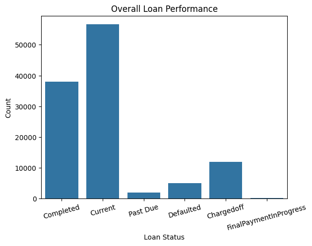

```python
count_plot('LoanStatusApprox', 'Loan Status', 'Overall Loan Performance')
```

**Interesting..** Prosper's customers seem to mostly pay. Moreover, the data is taken when a lot of loans are currently being held and are being repaid without being overdue. "Past Due" loans represent a smaller portion. They are not as prevalent as current or completed loans. A minimal number of loans are in the "FinalPaymentInProgress" stage, which means they are nearing completion. This makes sense as there shouldn't be a single day where all loans are nearing completion. Finally, this distribution suggests a healthy loan portfolio for Prosper with a large number of loans being repaid regularly and a smaller proportion facing repayment issues.

Next, let's explore and assess the creditworthiness of Posper's customers and borrowers to see their risk landscape.

```python
# Making sure dropping null values didn't drop entire rows.
loans.shape
```

```
(113937, 82)
```

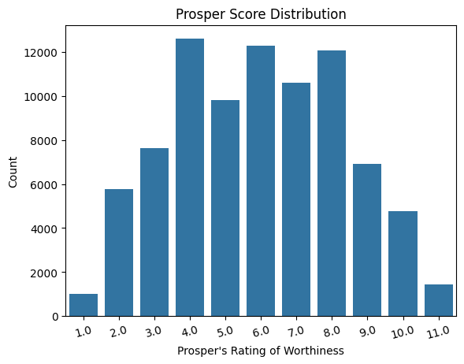

```python
count_plot('ProsperScore', 'Prosper\'s Rating of Worthiness', 'Prosper Score Distribution')
```

```python
# Getting the average Prosper Score to verify conclusion and observation.
loans['ProsperScore'].mean()
```

```
5.950066585742402
```

Now let me transition to the loan structure, starting with the common loan durations.

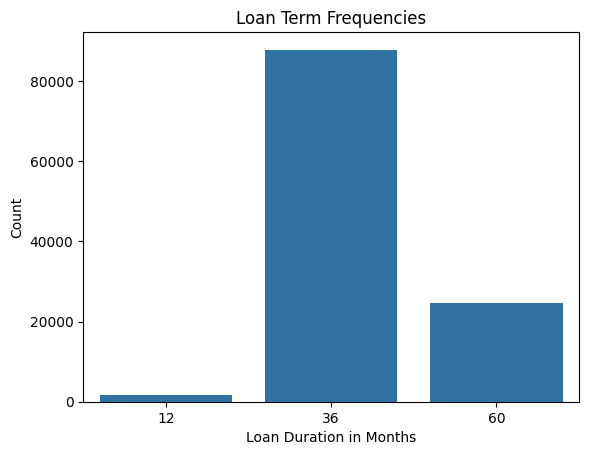

```python
count_plot('Term', 'Loan Duration in Months', 'Loan Term Frequencies', rot=0) #Plotting Loan Term as a count plot with no x-axis rotation.
```

**Oh.** I thought there'll be more options. Prosper only offers 3 choices... either 12 months, 36 months, or 60 months. Further bivariate and mutlivariate explorations can be carried out to identify if these options are offered to people according to their risk score (ProsperScore) or loan amount for example. Anyways, the highest frequency appears to occur at 36 months, which is 3 years. This could also depend on the "ListingCategory" (what the money had been used for). Also, more people opt in for the higher durations. Almost no one does 12 months as the loan term, but there are a few. Maybe due to lower interest paid.

The significant difference between the counts of 36-month and 60-month loans could indicate that borrowers tend to favor the lower total interest burden and quicker debt resolution associated with shorter loan terms, but not to the extent of cramming the payments into only a year.

Now, let me complete the structure by investigating the loan amounts given out.

```python
# I'll setup a function for future reference.
"""
Function to plot a histogram

x: String of targetted column
xlabel: String of label for the x axis
title: String for the title of the plot
binsize: An integer that represents the desired binsize for optimal plot view
"""
def histplot(x, binsize, xlabel, title):
    # Histogram from Seaborn's Library.
    sb.histplot(loans, x=x, bins=np.arange(0, loans[x].max()+binsize, binsize));
    plt.xlabel(xlabel) #Setting the X label
    plt.title(title) # Setting a title
    plt.show() # Showing the plot without internal messages
```

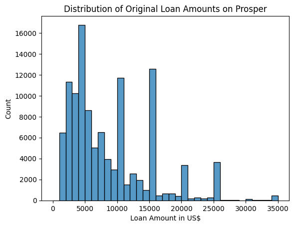

```python
# Histogram from Seaborn's Library. Bins are a list generated by numpy in increments of 1000$ to hold all loan amounts in a comprehendable way.
histplot('LoanOriginalAmount', 1000, "Loan Amount in US$", "Distribution of Original Loan Amounts on Prosper")
```

**Wow.** There's a general decrease in the amount of loans with higher amounts. With a number of spikes in the preferred frequencies of original loan amounts within the distribution, the highest spike is around the $4,000\$$ mark. This suggests that this mark is the most preferred loan amount. Moreover, there are notable peaks at approximately $10,000$$ and $15,000\$$, indicating other common loan amounts that may correspond to specific financial needs like car loans or substantial personal loans (further investigating this through bivariate or multivariate exploration is needed!). Then, the frequency of loans decreases significantly for amounts greater than $15,000$$, with fewer borrowers taking out larger loans. Additionally, there are relatively few loans with the smallest amounts (near $0$$), which may suggest a minimum loan amount threshold or less need for such small loans. Ultimately, this histogram shows a preference for mid-range loan amounts among borrowers, with diminishing frequencies at higher loan amounts. Also, I'm noticing some outlier at the 35,000 mark. Let's further investigate it!

```python
loans[loans['LoanOriginalAmount'] > 32500].LoanOriginalAmount.value_counts()
```

```
LoanOriginalAmount
35000    430
34000      5
33000      5
34999      3
33750      2
33500      2
33411      1
33710      1
34679      1
34700      1
Name: count, dtype: int64
```

```python
loans[loans['LoanOriginalAmount'] == 35000].ProsperScore.value_counts()
```

```
ProsperScore
8.0     92
10.0    81
9.0     80
7.0     67
11.0    64
6.0     27
5.0     12
4.0      6
3.0      1
Name: count, dtype: int64
```

This suggests that Prosper has limited the loan amount to exactly 35000, and several people (only ≈0.4%) have chosen this absurdly high amount. Also, these people mostly have a high rating, and lower risks associated. This makes sense. Prosper won't blindly hand out loans to people with low ratings and high risks except in really discrete cases.

```python
# Getting the relative frequencies of the score by dividing each count by the total counts
np.round(loans[loans['LoanOriginalAmount'] == 35000].ProsperScore.value_counts() / (loans[loans['LoanOriginalAmount'] == 35000].ProsperScore.value_counts().sum()/100))
```

```
ProsperScore
8.0     21.0
10.0    19.0
9.0     19.0
7.0     16.0
11.0    15.0
6.0      6.0
5.0      3.0
4.0      1.0
3.0      0.0
Name: count, dtype: float64
```

It appears clearly that around 10% of the people who take high loan amounts have a rating below 7, and more than 50% are people with 11, 10, or 9 prosper score. This solidifies my explaination above.

Anyways, back on track. Let me now delve into the cost of loans for borrowers, hinting at the interest rate landscape for prosper: The Borrower's Annual Percentage Rate (APR) for the loan.

```python
loans.BorrowerAPR.value_counts()
```

```
BorrowerAPR
0.35797    3672
0.35643    1644
0.37453    1260
0.30532     902
0.29510     747
           ...
0.37266       1
0.27518       1
0.18477       1
0.29961       1
0.19543       1
Name: count, Length: 6677, dtype: int64
```

Hm.. too much values, would require a histogram. Also, I'd like to convert from decimal form (e.g. 0.1) to percent form (10>%<)

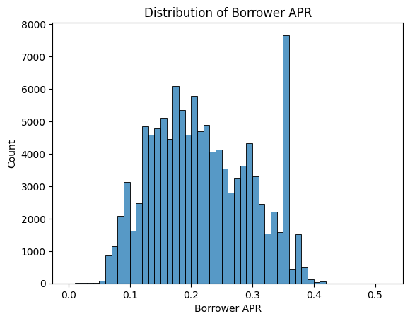

```python
histplot('BorrowerAPR', 0.01, "Borrower APR", "Distribution of Borrower APR") # Histogram in increments of 1%.
```

To top it all off, I'll now explore the consumer's background and context. Starting by understanding the purposes for which loans are sought, introducing context for loan usage.

```python
loans['ListingCategory (numeric)']
```

```
0          0
1          2
2          0
3         16
4          2
          ..
113932     1
113933     7
113934     1
113935     2
113936     1
Name: ListingCategory (numeric), Length: 113937, dtype: int64
```

Well that needs a little feature engineering!

```python
# Filling out a dictionary with the provided categories in the data's description.
categories = {
    0: "Not Available",
    1: "Debt Consolidation",
    2: "Home Improvement",
    3: "Business",
    4: "Personal Loan",
    5: "Student Use",
    6: "Auto",
    7: "Other",
    8: "Baby&Adoption",
    9: "Boat",
    10: "Cosmetic Procedure",
    11: "Engagement Ring",
    12: "Green Loans",
    13: "Household Expenses",
    14: "Large Purchases",
    15: "Medical/Dental",
    16: "Motorcycle",
    17: "RV",
    18: "Taxes",
    19: "Vacation",
    20: "Wedding Loans"
}

# New Column with actual category name as this data is categorical (non ordered) not numerical.
loans['ListingCategory'] = loans['ListingCategory (numeric)'].apply(lambda x: categories[x])
```

```python
loans['ListingCategory']
```

```
0              Not Available
1           Home Improvement
2              Not Available
3                 Motorcycle
4           Home Improvement
                 ...
113932    Debt Consolidation
113933                 Other
113934    Debt Consolidation
113935      Home Improvement
113936    Debt Consolidation
Name: ListingCategory, Length: 113937, dtype: object
```

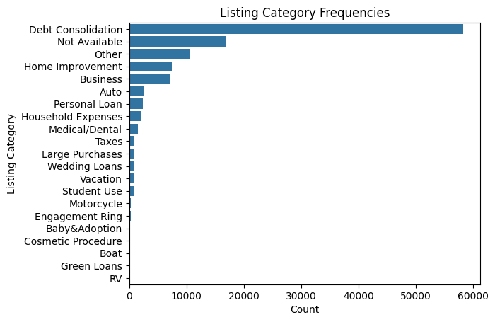

```python
# Plotting a 90° Count plot, with no y axis rotation and ordering by count.
rotated_count_plot("ListingCategory", "Listing Category", "Listing Category Frequencies", 0, loans["ListingCategory"].value_counts().index)
```

"Debt Consolidation" dominates the chart with the highest count! This chart indicates that the majority of borrowers are seeking loans for debt consolidation, while other purposes such as business investment, home improvements, and auto purchases also play significant roles. Less frequent purposes may indicate niche markets or less borrowing needs.

Finally, let me explore the financial background of borrowers (Incomes), rounding off the individual borrower's profile exploration.

```python
loans.IncomeRange.value_counts()
```

```
IncomeRange
$25,000-49,999    32192
$50,000-74,999    31050
$100,000+         17337
$75,000-99,999    16916
Not displayed      7741
$1-24,999          7274
Not employed        806
$0                  621
Name: count, dtype: int64
```

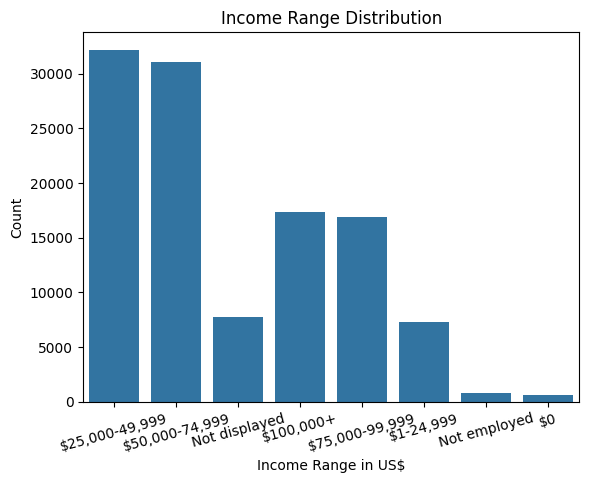

```python
# This column is already in a bin-like state, with buckets of values. A count plot serves well for this purpose.
count_plot("IncomeRange", "Income Range in US$", "Income Range Distribution")
```

For visual tidiness, it'd be better to order it based off of the dollar amounts. Let me do that real quick.

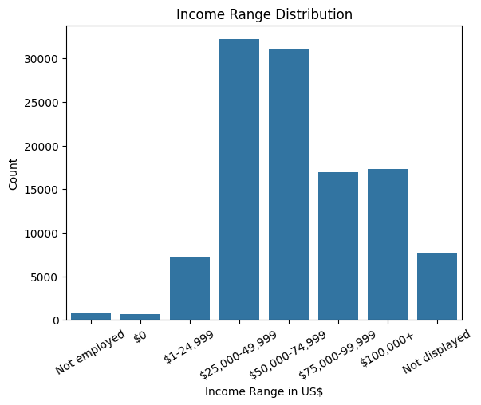

```python
# Manually Ordering the plot.
count_plot("IncomeRange", "Income Range in US$", "Income Range Distribution", rot=30, order=["Not employed", "$0", "$1-24,999", "$25,000-49,999", "$50,000-74,999", "$75,000-99,999", "$100,000+", "Not displayed"])
```

## Bivariate Exploration

Now we come to bivariate exploration where we can identify cool relationships between multiple piece of the data! This section would also address many concerns and questions that have rose from the univariate exploration. Starting off, I'll explore the relationship between risk assessment and borrowing costs.

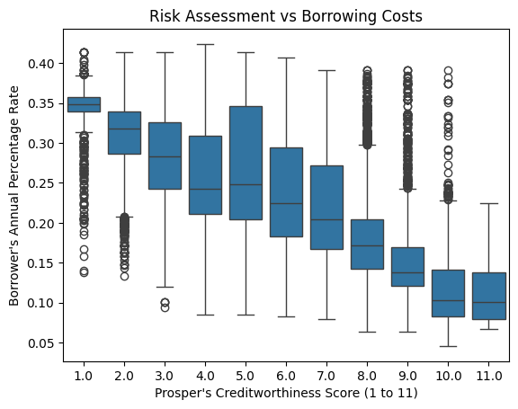

```python
sb.boxplot(data=loans, x="ProsperScore", y="BorrowerAPR")
plt.xlabel("Prosper's Creditworthiness Score (1 to 11)")
plt.ylabel("Borrower's Annual Percentage Rate")
plt.title("Risk Assessment vs Borrowing Costs")
plt.show()
```

**Interesting!** There are tons of outliers. Regardless, there appears to be a general decreasing trend in the borrowing costs (APR) when the borrower is of higher creditworthiness score. However, there is significant spread in APRs across all Prosper Scores, indicated by the length of the boxes and whiskers, which shows that there might be variability in rates even within the same risk category. This means that he highest Prosper Score (11) does not necessarily guarantee the lowest APR, indicating other factors may also influence the borrowing costs.

This box plot provides a clear visual representation of the relationship between the risk assessment of borrowers and the APR they receive, supporting the principle that better credit scores often result in more favorable borrowing costs, yet a mutlivariate exploration would help uncover other factors that play a role.

Next up, let me evaluate whether the prosper score is even reliable by comparing it against the actual fate of the loan (LoanStatus)

I'm also not interested the the current loans as I want to know the fate of loans that have ended.

```python
# Making a new column to hold ended loans' status
loans['EndedLoansStatus'] = loans.LoanStatusApprox.apply(lambda x: None if x == "Current" else x).dropna()
```

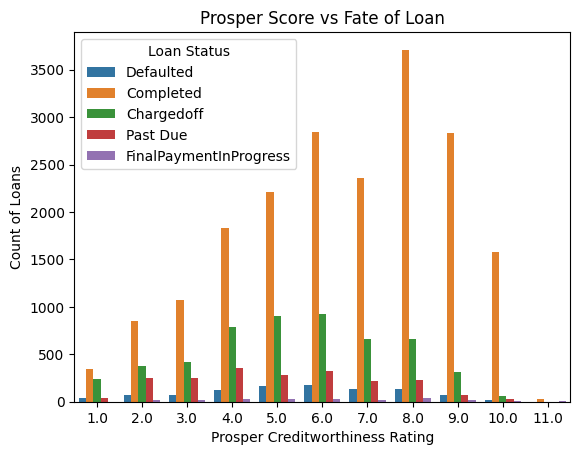

```python
# Setting up a cluster bar chart that represents the Prosper Score vs Fate of Loan
sb.countplot(data=loans, x="ProsperScore", hue='EndedLoansStatus')
plt.xlabel("Prosper Creditworthiness Rating")
plt.ylabel("Count of Loans")
plt.title("Prosper Score vs Fate of Loan")
plt.legend(title="Loan Status")
plt.show()
```

Hmm... I think I'm kind of stuck here... I think this chart is not reliable as for different ratings, there are a different number of loans, which would influence the total count. Can I make it relative somehow?

```python
# Total loan counts per score
loans_per_score = loans[loans["EndedLoansStatus"].isna() == False].groupby(["ProsperScore"]).ListingKey.count()
```

```python
# Counting loans in each category, then dividing by the loans per score to get a percentage relative to each score.
relative_loanstatus = loans.groupby(["ProsperScore", 'EndedLoansStatus']).ListingKey.count() / loans_per_score
relative_loanstatus = relative_loanstatus.reset_index("ProsperScore").rename(columns={"ListingKey": "Percentage"}) # Converting it into a pandas dataframe, plottable in a bar chart. Then, renamming the listingkey column used to simply count the unique number of loans to a more descriptive name.
```

```python
relative_loanstatus
```

| EndedLoansStatus | ProsperScore | Percentage |
| --- | --- | --- |
| Chargedoff | 1.0 | 0.358779 |
| Completed | 1.0 | 0.520611 |
| Defaulted | 1.0 | 0.056489 |
| FinalPaymentInProgress | 1.0 | 0.003053 |
| Past Due | 1.0 | 0.061069 |
| Chargedoff | 2.0 | 0.240127 |
| Completed | 2.0 | 0.540127 |
| Defaulted | 2.0 | 0.044586 |
| FinalPaymentInProgress | 2.0 | 0.014650 |
| Past Due | 2.0 | 0.160510 |
| Chargedoff | 3.0 | 0.225245 |
| Completed | 3.0 | 0.585963 |
| Defaulted | 3.0 | 0.040805 |
| FinalPaymentInProgress | 3.0 | 0.010881 |
| Past Due | 3.0 | 0.137106 |
| Chargedoff | 4.0 | 0.251363 |
| Completed | 4.0 | 0.586085 |
| Defaulted | 4.0 | 0.038153 |
| FinalPaymentInProgress | 4.0 | 0.008977 |
| Past Due | 4.0 | 0.115422 |
| Chargedoff | 5.0 | 0.252576 |
| Completed | 5.0 | 0.615984 |
| Defaulted | 5.0 | 0.045948 |
| FinalPaymentInProgress | 5.0 | 0.006962 |
| Past Due | 5.0 | 0.078530 |
| Chargedoff | 6.0 | 0.215266 |
| Completed | 6.0 | 0.662555 |
| Defaulted | 6.0 | 0.040261 |
| FinalPaymentInProgress | 6.0 | 0.005818 |
| Past Due | 6.0 | 0.076100 |
| Chargedoff | 7.0 | 0.195453 |
| Completed | 7.0 | 0.695896 |
| Defaulted | 7.0 | 0.039858 |
| FinalPaymentInProgress | 7.0 | 0.004724 |
| Past Due | 7.0 | 0.064068 |
| Chargedoff | 8.0 | 0.139098 |
| Completed | 8.0 | 0.775063 |
| Defaulted | 8.0 | 0.029031 |
| FinalPaymentInProgress | 8.0 | 0.008145 |
| Past Due | 8.0 | 0.048663 |
| Chargedoff | 9.0 | 0.093665 |
| Completed | 9.0 | 0.859654 |
| Defaulted | 9.0 | 0.021522 |
| FinalPaymentInProgress | 9.0 | 0.003941 |
| Past Due | 9.0 | 0.021219 |
| Chargedoff | 10.0 | 0.033608 |
| Completed | 10.0 | 0.929245 |
| Defaulted | 10.0 | 0.011792 |
| FinalPaymentInProgress | 10.0 | 0.006486 |
| Past Due | 10.0 | 0.018868 |
| Completed | 11.0 | 0.837838 |
| Defaulted | 11.0 | 0.027027 |
| FinalPaymentInProgress | 11.0 | 0.081081 |
| Past Due | 11.0 | 0.054054 |

As a check, these relative percentages add up to 100% within each score. Now let me try to construct my clustered bar chart.

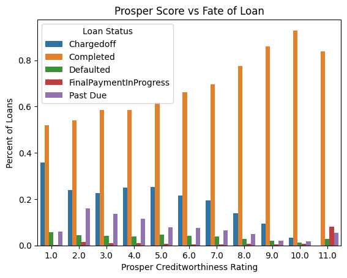

```python
# Setting up a cluster bar chart that represents the Prosper Score vs Fate of Loan
import matplotlib.patches as mpatches
sb.barplot(data=relative_loanstatus, x="ProsperScore", y="Percentage", hue='EndedLoansStatus')
plt.xlabel("Prosper Creditworthiness Rating")
plt.ylabel("Percent of Loans")
plt.title("Prosper Score vs Fate of Loan")
plt.legend(title="Loan Status")
plt.show()
```

Well that was something!! This required heavy feature engineering in order to bring out the actual trend. I had to normalize the data I had. This is particularly helpful for comparing across different score categories, especially if the number of loans varies widely between scores, which is the case here.

Now that we have the plot, let me talk about it for a bit. First off, Prosper's portfolio is looking great, as across all risk levels, most loans are completed, with varying percentages. Generally, as the rating increases, the likelihood of completed loans increases and the chargedoff likelihood decreases. Moreover, "Chargedoff" and "Defaulted" statuses appear less frequently as the Prosper Score increases, which supports the idea that the Prosper Score is an effective risk indicator. Overall, the chart suggests that the Prosper Score is a reliable predictor of loan outcomes, as higher scores appear to correlate with more favorable loan statuses.

Finally, let's finish off this bivariate exploration with the last financial dynamic: how the amount of money borrowed relates to the monthly repayment obligation. By examining the Loan Original Amount versus the Monthly Loan Payment, we can delve into the affordability and sustainability of loans from the borrower's perspective, which would give us insights into lending practices and financial planning.

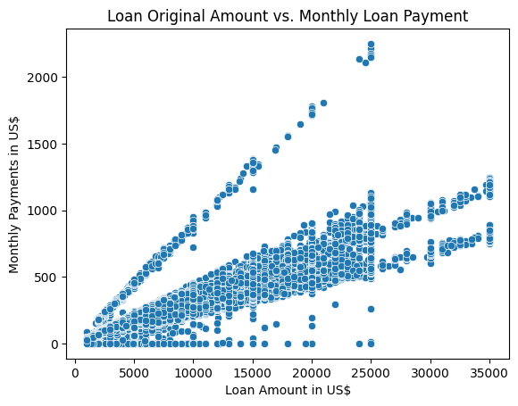

```python
sb.scatterplot(data=loans, x="LoanOriginalAmount", y="MonthlyLoanPayment")
plt.title("Loan Original Amount vs. Monthly Loan Payment")
plt.xlabel("Loan Amount in US$")
plt.ylabel("Monthly Payments in US$")
plt.show()
```

**Mind Blowing**... I mean, there's a general increase in monthly payments as the loan amount gets higher, which is basic financial knowledge. However, it seems that there are 3 different lines or areas of data concentration. Oh! The loan terms were 3. The loan term would influence the monthly payments of course. The 12 months loan would have to be repaid over a low number of months, increasing the number of monthly payments! This plot reinforces the concept that while the loan amount is a primary driver of the monthly payment, other factors like term and interest rates significantly influence the repayment schedule.

## Quick Summary

Let me now summarize the bivariate observations!

1. **Risk Assessment vs. Borrowing Costs**: There's a clear trend that shows as Prosper's Creditworthiness Score increases, the Borrower’s Annual Percentage Rate (APR) tends to decrease. This suggests that the Prosper Score is an effective measure for assessing credit risk and is used to determine the borrowing costs accordingly.
2. **Prosper Score vs. Fate of Loan**: Higher Prosper Scores generally correlate with a higher likelihood of loan completion and a lower likelihood of default or charge-off. This indicates that the Prosper Score is a reliable predictor of loan performance within the financial institution.
3. **Loan Original Amount vs. Monthly Loan Payment**: A direct relationship exists between the loan amount and the monthly payment, which means that higher loan amounts result in higher monthly payments. This relationship is expected, but the variability within loan amounts suggests that other factors like loan term and APR also affect the monthly payment amount.

## Multivariate Exploration

Alright now we are nearing the end! I want to finalize several questions I had from previous visualizations and drive this analysis home. Now, let me layer in the cost of borrowing with risk scores and loan outcomes, offering a comprehensive view of risk, cost, and performance.

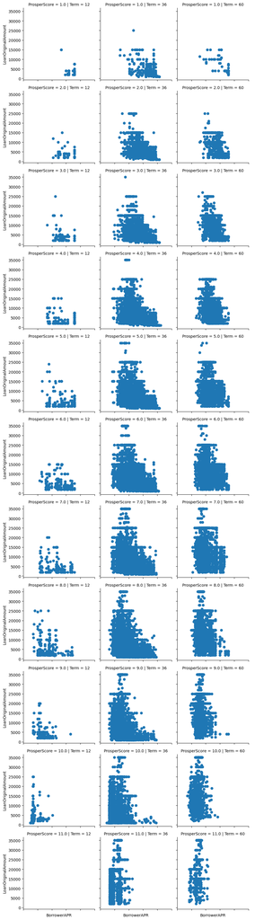

```python
graph = sb.FacetGrid(loans, row="ProsperScore", col="Term")
graph.map(plt.scatter, "BorrowerAPR", "LoanOriginalAmount").add_legend()
graph.set_xticklabels(rotation = 90)
[plt.setp(ax.get_xticklabels(), rotation=90) for ax in graph.axes.flat]
for ax in graph.axes.flatten():
    ax.tick_params(labelbottom=True)
plt.show()
```

Interesting! For term 12 months, as the prosper score increased, the borrower APR decreased. Also, for 12 months, the amount of the loan wasn't that high. Moving on to term 36 months, As the prosper score increased, the BorrowerAPR decreased and the loan amount increased. The term 60 months also shows a similar trend, but with more loan amounts probably due to the borrower having more time to repay the loan. Longer loan terms also show a trend towards higher APRs, as longer loans generally carry more risk (and thus higher costs) to the lender. Also, clusters can be made out from the data, which indicates common loan solutions offered to borrowers. There's also a very wide range of loan amounts or APRs at a specific Prosper Score or term, which might suggest variability in the loan products or the presence of subpopulations within the borrower profiles that aren't captured by Prosper Score alone.

Finally, I'll consider the borrower's other profile characteristic, like the DebtToIncomeRatio. I'll basically understand the impact of Borrower Financial Health on Loan Performance and Cost.

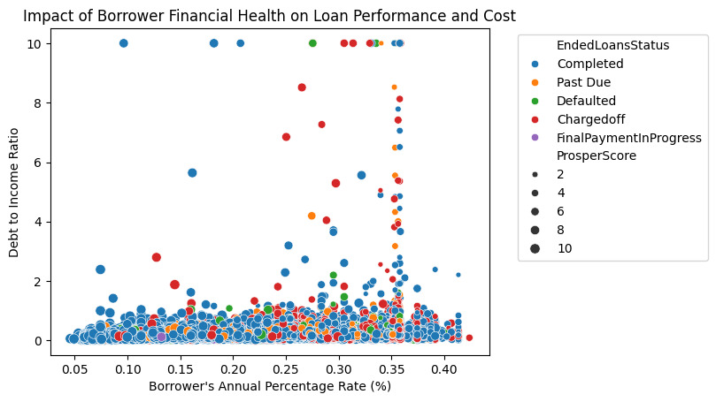

```python
sb.scatterplot(data=loans, x="BorrowerAPR", y="DebtToIncomeRatio", hue="EndedLoansStatus", size="ProsperScore")
# Moving the legend out of the plot
plt.legend(bbox_to_anchor=(1.05, 1), loc='upper left')
# Setting titles
plt.title("Impact of Borrower Financial Health on Loan Performance and Cost")
plt.xlabel("Borrower's Annual Percentage Rate (%)")
plt.ylabel("Debt to Income Ratio")
plt.show()
```

Well.. usually, people with low APR have high prosper score, and have completed their loans already with minor amounts of past dues and chargedoff. People with high Debt-Income Ratio tend to have a high APR with lower Prosper Score. This further adds onto the reliablity of ProsperScore and shows how the borrowing costs are affected by multiple vairables. Here are some observations to be made:

1. **Data Spread**: There's a wide spread of APR across all debt-to-income ratios, indicating variability in the rates that borrowers receive, regardless of their debt burden.
2. **Concentration**: A large number of loans have a debt-to-income ratio of less than 2. This concentration of data points suggests that most borrowers on the platform might have relatively manageable levels of debt compared to their income.
3. **Loan Status Distribution**: The distribution of loan statuses across the debt-to-income ratio appears somewhat uniform, with perhaps a slightly higher concentration of "Completed" and "FinalPaymentInProgress" loans at lower debt-to-income ratios, which might be expected.
4. **High Debt-to-Income Ratios**: There are few data points with very high debt-to-income ratios. While this is expected as lenders generally prefer lower ratios, these few loans seem to have a wide range of APRs, which may require further investigation to understand lending practices for high-risk borrowers.
5. **Loan Status Clusters**: It seems that loans with a status of "Chargedoff" or "Defaulted" are present across all debt-to-income ratios, which could suggest that factors other than the debt-to-income ratio are at play in determining loan performance.
6. **Abnormalities**: There are loans with a debt-to-income ratio of 10, which is unusually high and could be a data entry error, a reflection of certain high-risk lending practices, or indicative of borrowers with very high levels of debt relative to their income.

This chart does show the impact of debt-to-income ratio on APR and loan status, but the findings aren't necessarily conclusive. It would be worth investigating if loans with very high debt-to-income ratios are receiving APRs that properly reflect their heightened risk. Additionally, exploring other factors that might contribute to loan performance, such as employment status or credit history, could provide a more comprehensive understanding, but would really make this plot unreadable.

## Summary

**Facet Plot Summary:** This revealed that with shorter-term loans of 12 months, there is a noticeable trend where a higher Prosper Score correlates with a lower borrower APR. Additionally, for these shorter-term loans, the loan amounts are not particularly high. As we move to longer terms, such as 36 and 60 months, the same inverse relationship between Prosper Score and APR persists, but the loan amounts tend to be higher, likely due to the extended repayment period which reduces the monthly payment amount. Moreover, the presence of higher APRs for longer terms suggests that a compensation is often asked for the increased risk associated with longer loan durations. However, the wide range of loan amounts and APRs within specific Prosper Scores or loan terms suggests there are nuances in borrower profiles and loan structures not fully captured by the Prosper Score alone.

This overall analysis points out that while the Prosper Score, loan term, and debt-to-income ratio provide a framework for understanding loan performance and cost, the relationship between these factors is intricate. Other hidden variables or external factors may influence the loan outcome and APR. Ultimately, the analysis underscores the multifaceted nature of lending risk and the need for comprehensive risk assessment models.

## Conclusions

This data exploration has taken us through quite a lot of findings about the details of how the loans are performing on the Prosper platform. Here is a recap:

1. **Distribution of Loan Status**: The current distribution has a majority of loans showing that active repayment is reflected in the lending app. Completed has been a lesser, though important, proportion of the proportion of these. However, there are delinquencies and charge-offs, but they form a small percentage, which indicates good loan performance.
2. **Prosper score distribution**: Most borrowers have a moderate score; very few have a very high or very low score. This central clustering of scoring attributes throws in some of the borrowers into the extreme range and provides a moderate risk profile for most of them on the platform.
3. **Loan term frequencies**: The 36 months of a loan term shines as preferable, likely pointing at the borrower's balance between the monthly payment affordance and the total loan cost.
4. **APR Trends**: Borrower APRs show a wide range but with clustering at certain rates, possibly indicative of standardized rate offerings based on risk assessment.
5. **Loan Original Amount and Monthly Payments:** This, too, goes in tandem to indicate a direct relationship. Bigger loans carry higher monthly payments, though with variance showing a possible participation of interest rate and loan term.
6. **Bivariate Relationships**: The better the score, the higher the likelihood of getting a lower APR, which would also validate the score as a measure of creditworthiness. It is quite a reasonable indicator to find an inverse relationship of Prosper Scores with negative loan outcomes (such as "Defaulted" and "Chargedoff") in support of predictive reliability. That made Loan Original Amount vs. Monthly Loan Payment reflect the expected trend of higher loans bringing higher monthly payments, but with variability in place pointing to the impact of other factors.
7. **Multivariate Insights**: The interplay between Prosper Score, Loan Term, and APR suggests that while the risk is evaluated consistently, its effect on loan cost is nuanced. "The debt-to-income ratio influences both loan performance and costs but not directly, showing some complexity with relation to default risk. Reflecting over our exploration, we started from a lower level of insight through the univariate analyses, which would set the stage for having insight into the dataset. Next, bivariate analyses will take us further in the identification of relations and trends that are occurring among pairs of variables. Lastly, our multivariate investigation brings together several facets that point to complex interaction dictating loan performance and borrower costs.

Clear patterns can be perceived, but it also needs to be noted some exceptions and complexities that remind us that although data can tell us much, this is usually something that, to be built, needs to be further processed in order to make the full story. All this data journey serves to really underscore the necessity: really dig deep and come up with some meaning out of it, and in the process remain open for insight that might actually challenge the frame. It underscores the power that data visualization and statistical analysis can have in turning raw data into actionable intelligence.